# Aprendizaje supervisado: modelos lineales

#### 5.3.7 Pregunta 7

> Piensa el código necesario para obtener las 2 siguientes gráficas e interprétalas.

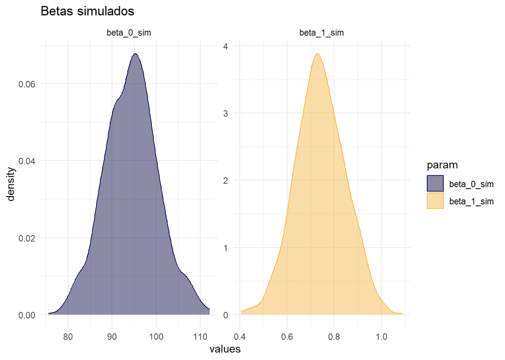

```r
beta_0_sim <-
  rnorm(n = 1000, mean = ajuste_lineal$coefficients[1], sd = 6.0564)
beta_1_sim <-
  rnorm(n = 1000, mean = ajuste_lineal$coefficients[2], sd = 0.1065)
betas_sim <-
  tibble(beta_0_sim, beta_1_sim) |>
  pivot_longer(cols = everything(), names_to = "param", values_to = "values")

ggplot(betas_sim) +
  geom_density(aes(x = values, fill = param, color = param),
               alpha = 0.5) +
  MetBrewer::scale_color_met_d("Renoir") +
  MetBrewer::scale_fill_met_d("Renoir") +
  facet_wrap(~param, scales = "free") +
  theme_minimal() +
  labs(title = "Betas simulados")
```

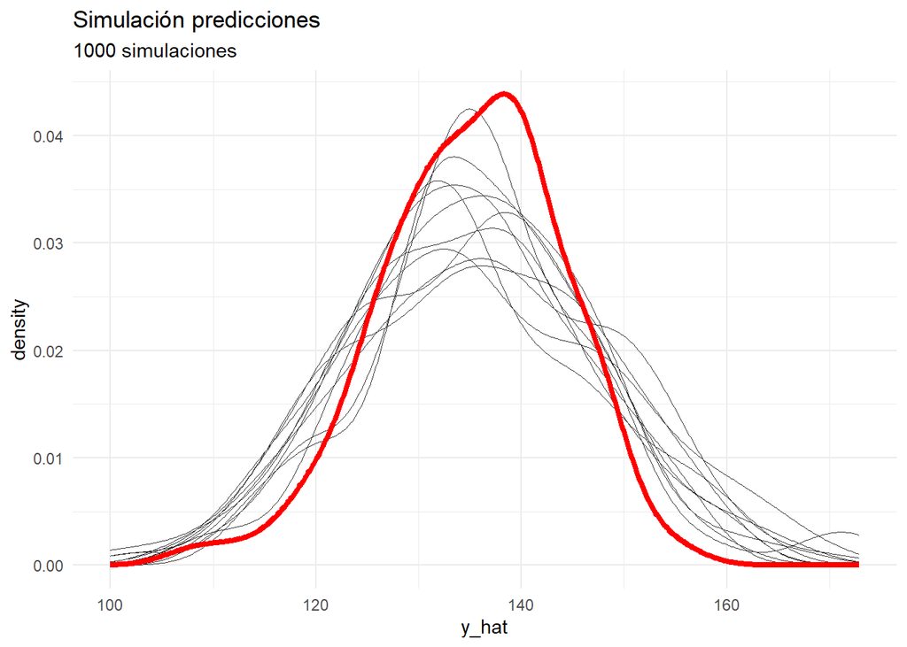

```r
predic_simul <-
  datos |>
  reframe("id_simul" = rep(1:1000, each = length(edad)),
          "x" = rep(edad, 1000),
          "y_hat" = beta_0_sim + beta_1_sim*x)
ggplot(predic_simul) +
  geom_density(aes(x = y_hat, group = id_simul),
               color = "grey20", alpha = 0.2, linewidth = 0.1) +
  geom_density(data =
                 tibble("y_hat" = ajuste_lineal$fitted.values),
               aes(x = y_hat), color = "red", linewidth = 1.5) +
  theme_minimal() +
  labs(title = "Simulación predicciones",
       subtitle = "1000 simulaciones")
```

## 6 Clase 11

### 6.1 🐣 Caso práctico I: simulación

#### 6.1.1 Pregunta 1

> Simula unos datos ($n = 500$) bajo la hipótesis (junta $y$ y $x$ en la misma tabla) de que

$$Y = -1 + 3*X + \varepsilon, \quad X \sim N(-3, \sigma = 1.2), \quad \varepsilon \sim N(0, \sigma = 3)$$

```r
eps <- rnorm(n = 500, mean = 0, sd = 3)
x <- rnorm(n = 500, mean = -3, sd = 1.2)
y <- -1 + 3*x + eps
datos <- tibble(y, x)
```

#### 6.1.2 Pregunta 2

> Ajusta un modelo de regresión lineal univariante e interpreta todo lo que consideres (asume que la diagnosis se cumple ya que lo hemos simulado para que así sea)

```r
ajuste_inicial <- lm(data = datos, y ~ x)
ajuste_inicial |> summary()
```

```
Call:
lm(formula = y ~ x, data = datos)

Residuals:
    Min      1Q  Median      3Q     Max
-9.4743 -1.7794 -0.0039  1.9051  8.2603

Coefficients:
            Estimate Std. Error t value Pr(>|t|)
(Intercept)  -0.8828     0.3247  -2.719  0.00677 **
x             3.1142     0.1001  31.106  < 2e-16 ***
---
Signif. codes:  0 '***' 0.001 '**' 0.01 '*' 0.05 '.' 0.1 ' ' 1

Residual standard error: 2.839 on 498 degrees of freedom
Multiple R-squared:  0.6602,    Adjusted R-squared:  0.6595
F-statistic: 967.6 on 1 and 498 DF,  p-value: < 2.2e-16
```

#### 6.1.3 Pregunta 3

> Diseña un bucle de 490 iteraciones de manera que, en cada iteración, incorpores a la tabla una nueva predictora $X_i \sim N(0, 1)$. Fíjate que las **predictoras nuevas no tienen ningún tipo de relación con $y$** (son “basura” para el modelo). En cada iteración haz un ajuste de $y$ vs todas y guarda su $R2$

```r
R2 <- c()
for (i in 1:490) {

  datos[, i + 2] <-  rnorm(n = 500, mean = 0, sd = 1)
  R2[i] <- (lm(data = datos, y ~ .) |> summary())$r.squared

}
```

#### 6.1.4 Pregunta 4

> Crea una tabla con dos columnas: iteración y R2. Tras ello visualiza la evolución del R2 en función del número de la iteración (=número de predictoras basura). Interpreta lo que observes

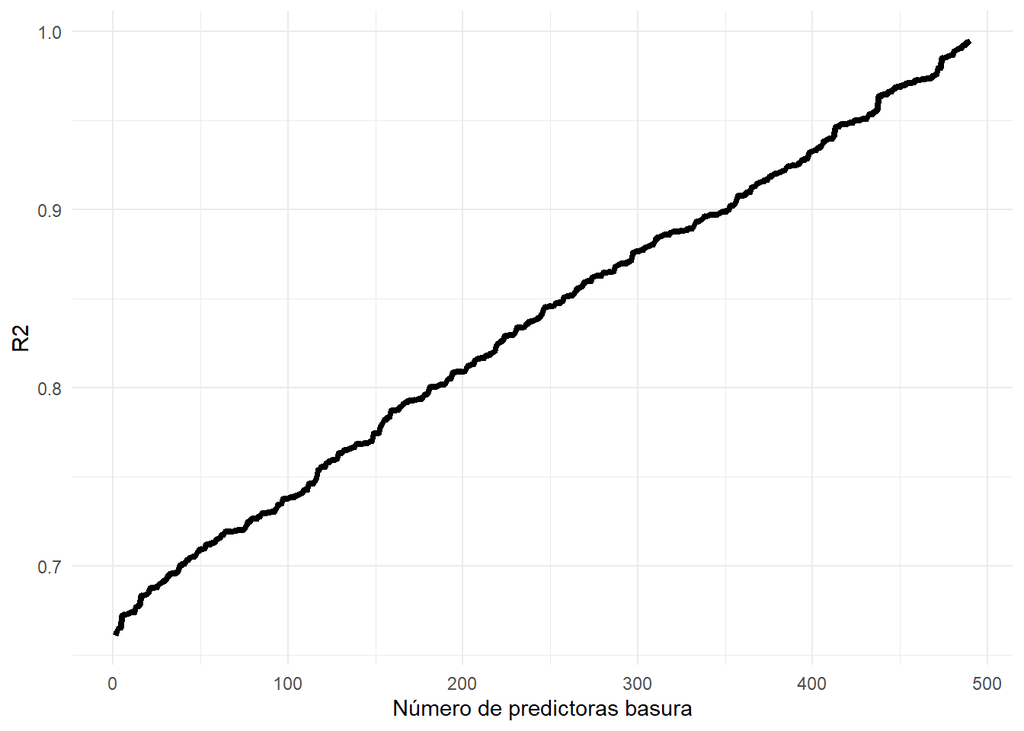

```r
tabla_R2 <- tibble("iter" = 1:490, "R2" = R2)
ggplot(tabla_R2) +
  geom_line(aes(x = iter, y = R2), linewidth = 1.5) +
  theme_minimal() +
  labs(x = "Número de predictoras basura")
```

```r
# Moraleja: a mayor nº de predictoras, más se infla R^2
# ¡aunque sean basura!
```

#### 6.1.5 Pregunta 5

> Simula una colección de datos ($n = 500$) bajo la hipótesis de que $Y = -1 + 3*X_1 + \varepsilon$ con $X \sim N(-3, \sigma = 1.2)$ y
- `datos_1`: $\varepsilon \sim N(0, \sigma = 0.5)$, `datos_2`: $\varepsilon \sim N(0, \sigma = 1)$
- `datos_3`: $\varepsilon \sim N(0, \sigma = 2)$, `datos_4`: $\varepsilon \sim N(0, \sigma = 4)$
- `datos_5`: $\varepsilon \sim N(0, \sigma = 8)$, `datos_6`: $\varepsilon \sim N(0, \sigma = 12)$

```r
x <- rnorm(n = 500, mean = -3, sd = 1.2)
y <- -1 + 3*x

datos_1 <- tibble("y" = y + rnorm(n = 500, mean = 0, sd = 0.5), x)
datos_2 <- tibble("y" = y + rnorm(n = 500, mean = 0, sd = 1), x)
datos_3 <- tibble("y" = y + rnorm(n = 500, mean = 0, sd = 2), x)
datos_4 <- tibble("y" = y + rnorm(n = 500, mean = 0, sd = 4), x)
datos_5 <- tibble("y" = y + rnorm(n = 500, mean = 0, sd = 8), x)
datos_6 <- tibble("y" = y + rnorm(n = 500, mean = 0, sd = 12), x)
```

#### 6.1.6 Pregunta 6

> Realiza los 6 ajustes, uno para cada dataset, siempre $y$ vs $x$. **IMPORTANTE**: fíjate que la parte a explicar, la modelizable, la parte no aleatoria, ¡es siempre la misma! Así que el modelo debería ser parecido siempre. Usa `compare_performance()` para compararlos.

```r
ajuste_1 <- lm(data = datos_1, formula = y ~ x)
ajuste_2 <- lm(data = datos_2, formula = y ~ x)
ajuste_3 <- lm(data = datos_3, formula = y ~ x)
ajuste_4 <- lm(data = datos_4, formula = y ~ x)
ajuste_5 <- lm(data = datos_5, formula = y ~ x)
ajuste_6 <- lm(data = datos_6, formula = y ~ x)

performance::compare_performance(ajuste_1, ajuste_2, ajuste_3, ajuste_4, ajuste_5, ajuste_6)
# ¡La supuesta calidad del ajuste desciende drásticamente,
# siendo igual de bueno! La parte que se puede predecir está
# perfectamente ajustada pero tenemos más ruido en los
# datos (ruido = no modelizable)
```

[output not shown]

#### 6.1.7 Pregunta 7

> Y si tenemos un modelo con un alto $R^2$, ¿no hace falta que cumpla las hipótesis?. Basándote en $X \sim N(-3, \sigma = 1.5)$ y $\varepsilon \sim N(0, \sigma = 1)$ con $n = 500$, simula un modelo entre $X$ e $Y$ que incumpla la hipótesis de linealidad.

```r
eps <- rnorm(n = 500, mean = 0, sd = 1)
x <- rnorm(n = 500, mean = -3, sd = 1.5)
y <- -1.5 + 2*x - 3*x^2 # por ejemplo
datos <- tibble(x, y)
```

#### 6.1.8 Pregunta 8

> Realiza el ajuste lineal y visualiza residuos vs valores predichos.

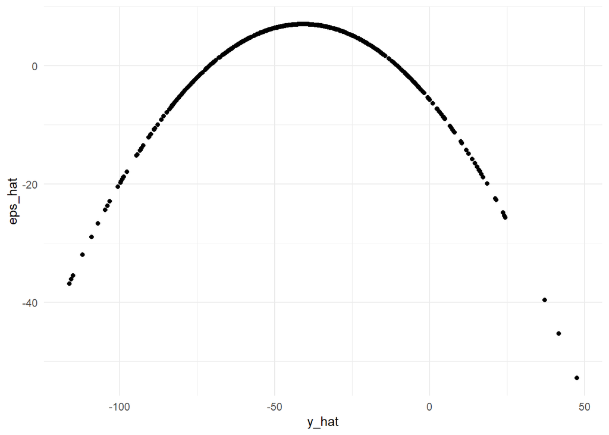

```r
ajuste <- lm(data = datos, y ~ x)

tabla_residuos <- tibble("eps_hat" = ajuste$residuals, "y_hat" = ajuste$fitted.values)
ggplot(tabla_residuos) +
  geom_point(aes(x = y_hat, y = eps_hat)) +
  theme_minimal()
```

```r
# deberías observar en los residuos el patrón que en
# los datos no modelizaste o no tuviste en cuenta
```

#### 6.1.9 Pregunta 9

Junta todo en un dataset de 3 columnas: y, x y $\sigma_i$. ¿Qué hipótesis se incumplen?

```r
x <- seq(0.01, 2, l = 500)
eps <- rnorm(n = 500, mean = 0, sd = 0.2 * x^2)
y <- 1 - 2 * x * (1 + 0.25*sin(4 * pi * x)) + eps
datos <- tibble("y" = y, "x" = x, "sigma" =  0.2 * x^2)
```

#### 6.1.10 Pregunta 10

> Realiza el ajuste de $y ~ x$ y observa el $R^2$

```r
ajuste_lineal <- lm(data = datos, formula = y ~ x)
ajuste_lineal |> summary()
```

```
Call:
lm(formula = y ~ x, data = datos)

Residuals:
     Min       1Q   Median       3Q      Max
-2.07634 -0.25633  0.03227  0.22033  1.81440

Coefficients:
            Estimate Std. Error t value Pr(>|t|)
(Intercept)  0.91620    0.04742   19.32   <2e-16 ***
x           -1.86795    0.04095  -45.62   <2e-16 ***
---
Signif. codes:  0 '***' 0.001 '**' 0.01 '*' 0.05 '.' 0.1 ' ' 1

Residual standard error: 0.527 on 498 degrees of freedom
Multiple R-squared:  0.8069,    Adjusted R-squared:  0.8065
F-statistic:  2081 on 1 and 498 DF,  p-value: < 2.2e-16
```

#### 6.1.11 Pregunta 11

> Fíjate que tenemos un $R^2$ bastante alto pero… ¿tiene sentido su interpretación? Pinta en un diagrama de puntos + recta de regresión los datos $x$ vs $y$.

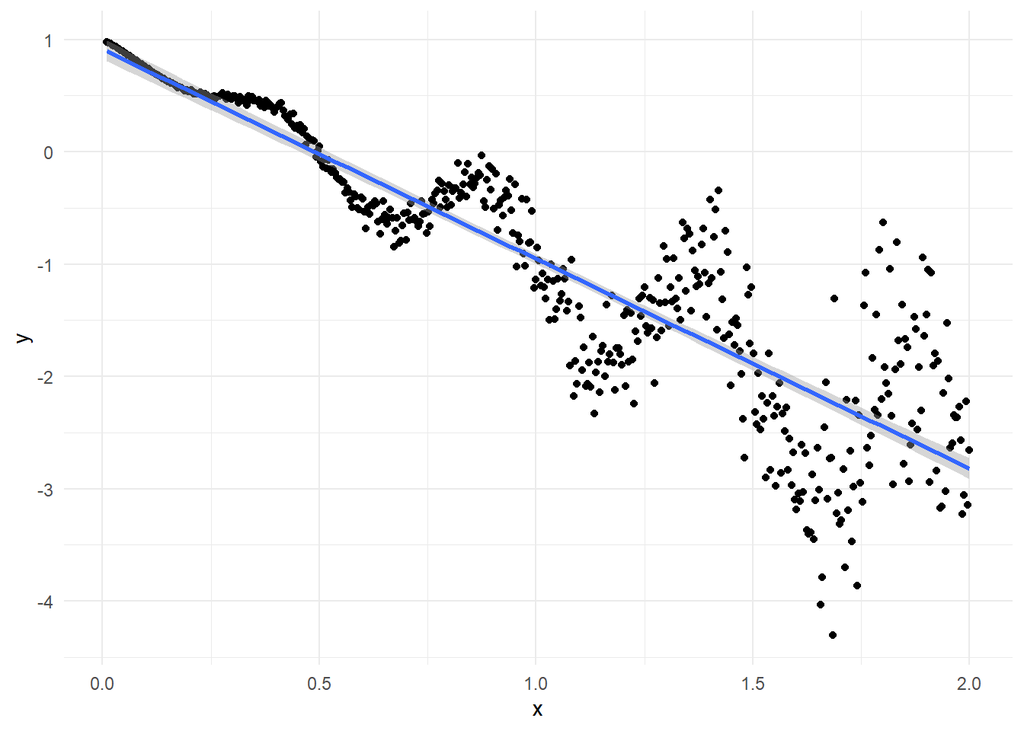

```r
ggplot(datos, aes(x = x, y = y)) +
  geom_point() +
  geom_smooth(method = "lm") +
  theme_minimal()
```

```r
# Aunque el R^2 es bastante alto, el modelo no tiene sentido,
# dando estimaciones cada vez más erradas
```